# Duncan Data Analysis

J. Fox and S. Weisberg

2018-04-24

This R Markdown file reproduces the data analysis described in Section 1.5 of *An R Companion to Applied Linear Regression, 3rd Edition*. See the text for further explanation.

# Preliminaries

As a first step, we load the **car** package, and examine the first few rows of the `Duncan` data:

```r
library("car") # load car and carData packages
head(Duncan, n=10)
```

```
##            type income education prestige
## accountant prof     62        86       82
## pilot      prof     72        76       83
## architect  prof     75        92       90
## author     prof     55        90       76
## chemist    prof     64        86       90
## minister   prof     21        84       87
## professor  prof     64        93       93
## dentist    prof     80       100       90
## reporter     wc     67        87       52
## engineer   prof     72        86       88
```

```r
dim(Duncan)
```

```
## [1] 45  4
```

Obtain summary statistics for the variables in `Duncan`:

```r
summary(Duncan)
```

```
##    type        income        education         prestige
##  bc  :21   Min.   : 7.00   Min.   :  7.00   Min.   : 3.00
##  prof:18   1st Qu.:21.00   1st Qu.: 26.00   1st Qu.:16.00
##  wc  : 6   Median :42.00   Median : 45.00   Median :41.00
##            Mean   :41.87   Mean   : 52.56   Mean   :47.69
##            3rd Qu.:64.00   3rd Qu.: 84.00   3rd Qu.:81.00
##            Max.   :81.00   Max.   :100.00   Max.   :97.00
```

As a first graph, we view a histogram of the variable `prestige`:

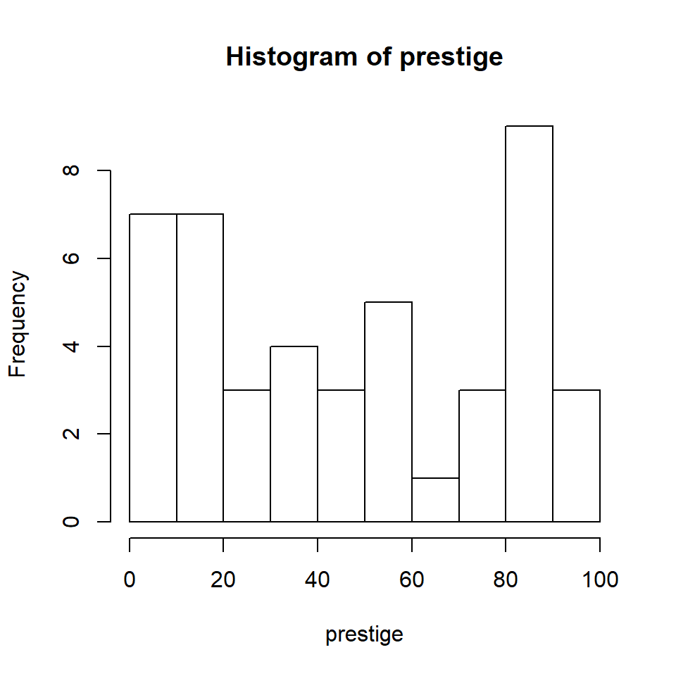

```r
with(Duncan, hist(prestige))
```

## 1.5.1 Examining the Data

The `scatterplotMatrix()` function in the **car** package produces scatterplots for all paris of variables. A few relatively remote points are marked by case names, in this case by occupation.

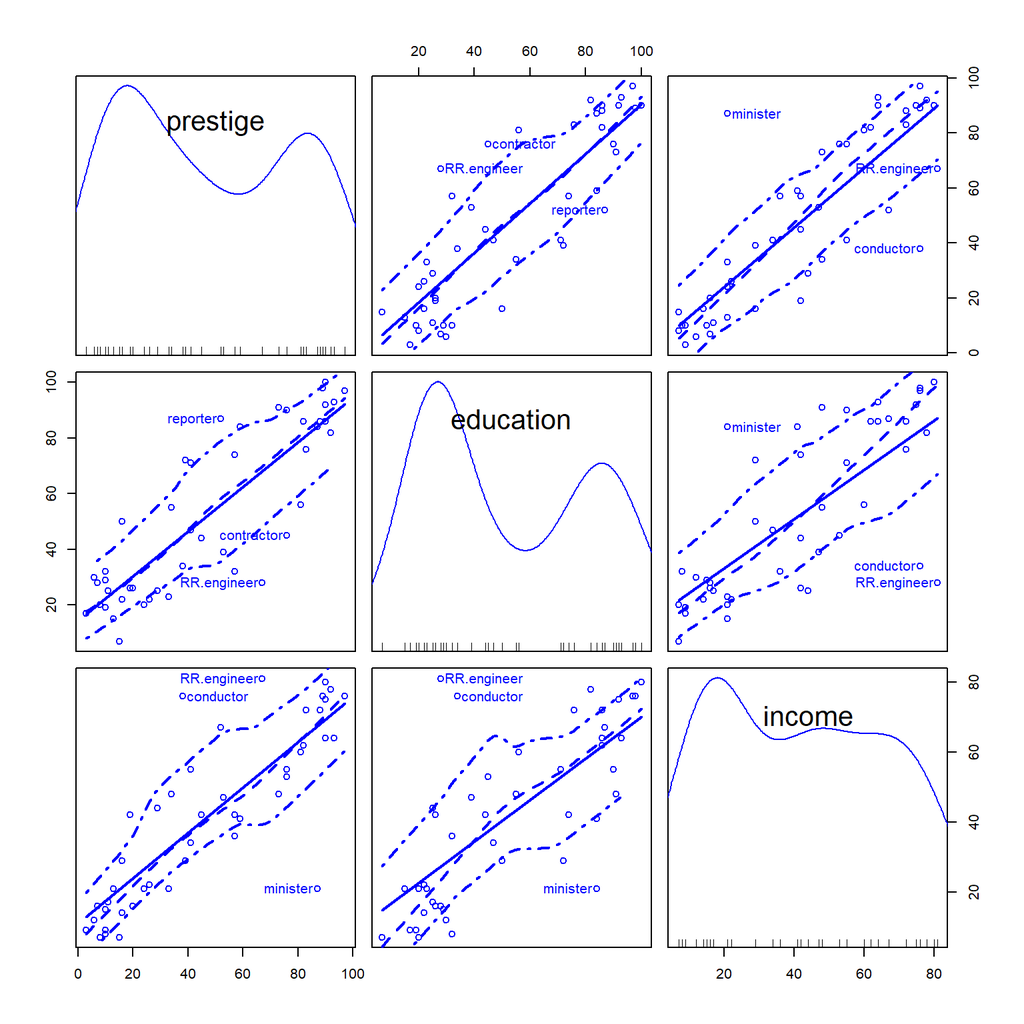

```r
scatterplotMatrix( ~ prestige + education + income,
    id=list(n=3), data=Duncan)
```

## 1.5.2 Regression Analysis

We use the`lm()` function to fit a linear regression model to the data:

```r
(duncan.model <- lm(prestige ~ education + income, data=Duncan))
```

```
##
## Call:
## lm(formula = prestige ~ education + income, data = Duncan)
##
## Coefficients:
## (Intercept)    education       income
##     -6.0647       0.5458       0.5987
```

```r
summary(duncan.model)
```

```
##
## Call:
## lm(formula = prestige ~ education + income, data = Duncan)
##
## Residuals:
##     Min      1Q  Median      3Q     Max
## -29.538  -6.417   0.655   6.605  34.641
##
## Coefficients:
##             Estimate Std. Error t value Pr(>|t|)
## (Intercept) -6.06466    4.27194  -1.420    0.163
## education    0.54583    0.09825   5.555 1.73e-06 ***
## income       0.59873    0.11967   5.003 1.05e-05 ***
## ---
## Signif. codes:  0 '***' 0.001 '**' 0.01 '*' 0.05 '.' 0.1 ' ' 1
##
## Residual standard error: 13.37 on 42 degrees of freedom
## Multiple R-squared:  0.8282, Adjusted R-squared:   0.82
## F-statistic: 101.2 on 2 and 42 DF,  p-value: < 2.2e-16
```

The `brief()` and `S()` functions, both in the **car** package, provide alternative summaries of a regression fit.

## 1.5.3 Regression Diagnostics

The `rstudent()` function returns studentized residuals, and the `densityPlot()` function fits an adaptive kernel density estimator to the distribution of the studentized residuals:

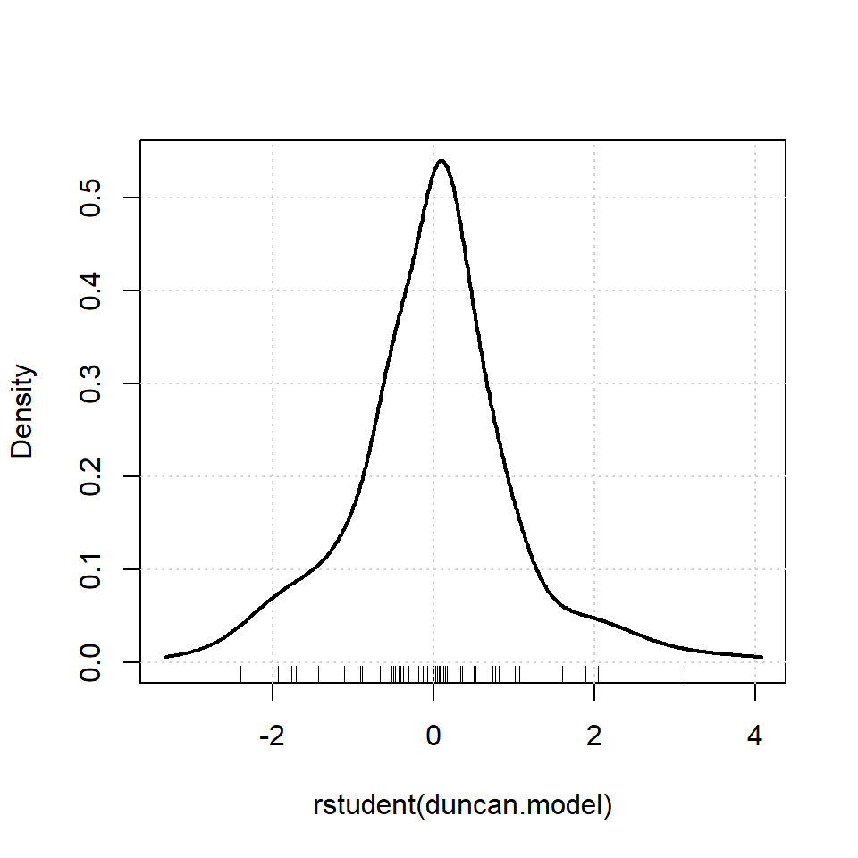

```r
densityPlot(rstudent(duncan.model))
```

A `qqPlot()` can be used as a check for nonnormal errors, comparing the studentized residuals to a t-distribution:

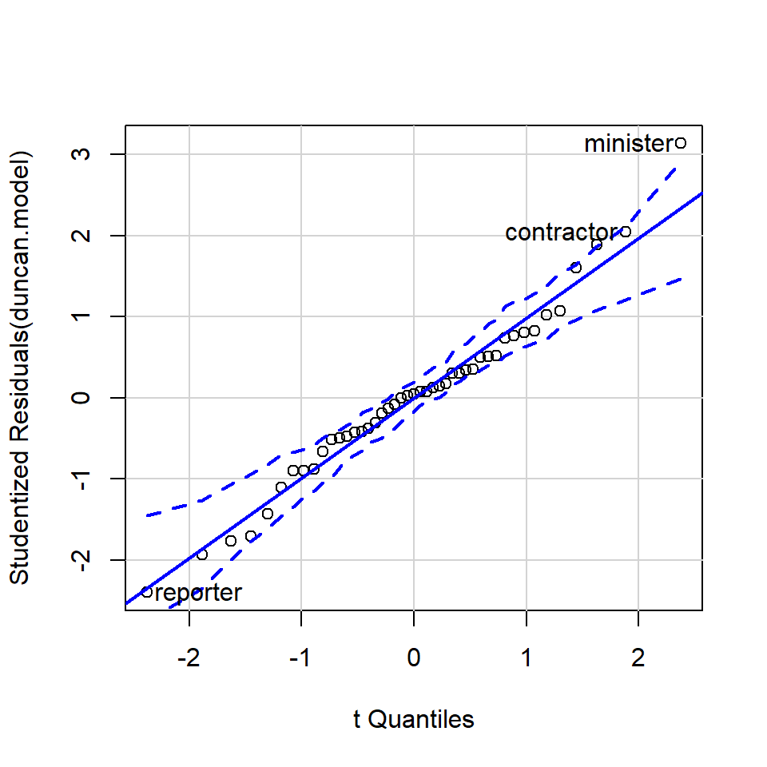

```
##   minister   reporter contractor
##          6          9         17
```

```r
qqPlot(duncan.model, id=list(n=3))
```

This next function tests for outliers in the regression:

```r
outlierTest(duncan.model)
```

```
## No Studentized residuals with Bonferonni p < 0.05
## Largest |rstudent|:
##          rstudent unadjusted p-value Bonferonni p
## minister 3.134519          0.0031772      0.14297
```

This graph displays influence measures in index plots:

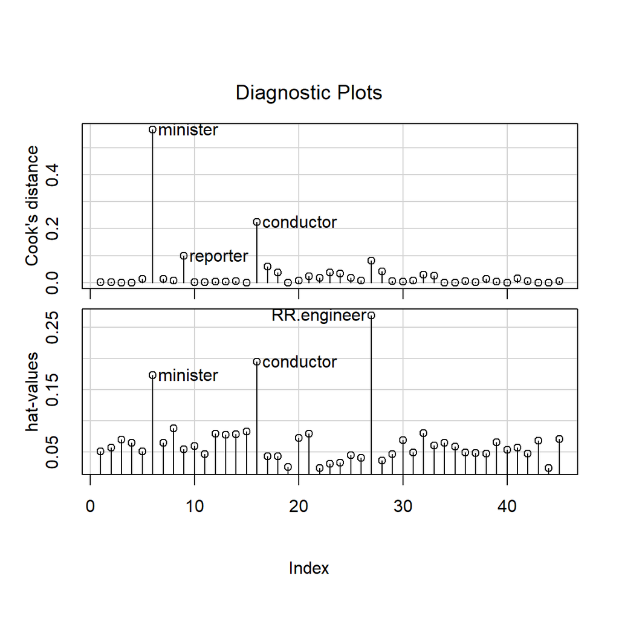

```r
influenceIndexPlot(duncan.model, vars=c("Cook", "hat"),
    id=list(n=3))
```

Added-variable plots for Duncan’s regression, looking for influential cases:

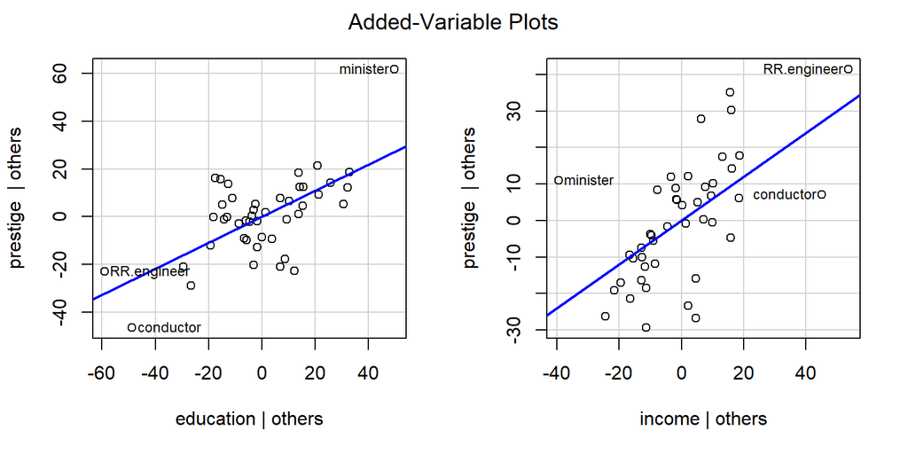

```r
avPlots(duncan.model,
    id=list(cex=0.75, n=3, method="mahal"))
```

Component-plus-residual plots for the regression, checking for nonlinearity:

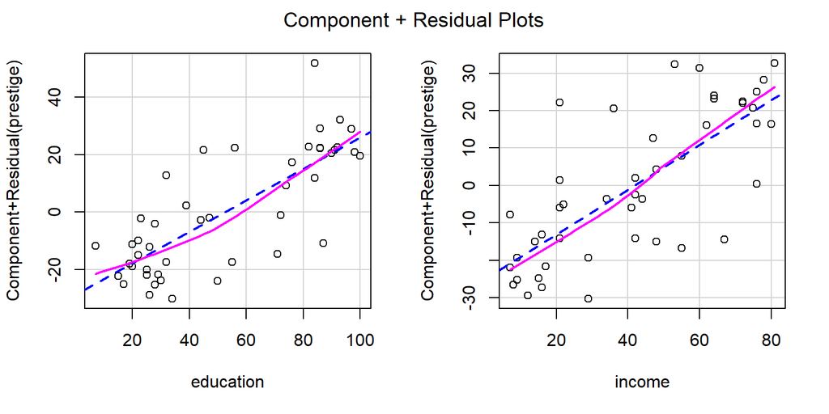

```r
crPlots(duncan.model, smooth=list(span=0.7))
```

Tests for non-constant error variance:

```r
ncvTest(duncan.model)
```

```
## Non-constant Variance Score Test
## Variance formula: ~ fitted.values
## Chisquare = 0.3810967, Df = 1, p = 0.53702
```

```r
ncvTest(duncan.model, var.formula= ~ income + education)
```

```
## Non-constant Variance Score Test
## Variance formula: ~ income + education
## Chisquare = 0.6976023, Df = 2, p = 0.70553
```

Removing the cases `"minister"` and “`conductor’”:

```r
whichNames(c("minister", "conductor"), Duncan)
```

```
##  minister conductor
##         6        16
```

```r
duncan.model.2 <- update(duncan.model, subset=-c(6, 16))
summary(duncan.model.2)
```

```
##
## Call:
## lm(formula = prestige ~ education + income, data = Duncan, subset = -c(6,
##     16))
##
## Residuals:
##     Min      1Q  Median      3Q     Max
## -28.612  -5.898   1.937   5.616  21.551
##
## Coefficients:
##             Estimate Std. Error t value Pr(>|t|)
## (Intercept) -6.40899    3.65263  -1.755   0.0870 .
## education    0.33224    0.09875   3.364   0.0017 **
## income       0.86740    0.12198   7.111 1.31e-08 ***
## ---
## Signif. codes:  0 '***' 0.001 '**' 0.01 '*' 0.05 '.' 0.1 ' ' 1
##
## Residual standard error: 11.42 on 40 degrees of freedom
## Multiple R-squared:  0.876,  Adjusted R-squared:  0.8698
## F-statistic: 141.3 on 2 and 40 DF,  p-value: < 2.2e-16
```

Comparing the regressions with and without these two cases:

```r
compareCoefs(duncan.model, duncan.model.2)
```

```
## Calls:
## 1: lm(formula = prestige ~ education + income, data = Duncan)
## 2: lm(formula = prestige ~ education + income, data = Duncan, subset =
##   -c(6, 16))
##
##             Model 1 Model 2
## (Intercept)   -6.06   -6.41
## SE             4.27    3.65
##
## education    0.5458  0.3322
## SE           0.0983  0.0987
##
## income        0.599   0.867
## SE            0.120   0.122
##
```